# Aprendizaje no supervisado: Detección de biomarcadores (FOCI) y redes de interacción (reglas de asociación)

María Lourdes Linares Barrera

# Configuración de variables de script y directorio de trabajo

Establecemos como directorio de trabajo (workspace) el directorio en el que se encuentra el fichero.

```r
library(rstudioapi)

workspace_path <- rstudioapi::getActiveDocumentContext()$path
setwd(dirname(workspace_path))

print( paste("Workspace:",getwd()) )
```

Configuramos las variables del script para el conjunto de datos.

```r
# Caracteristicas de los datos

dataset_name <- "prostateCancer"      # conjunto de datos
not_gene_columns <- c("group")        # columnas que no son genes
groupv0 <- "normal"                   # valores codificados como 0 y 1 en la clasificacion (diagnostico)
groupv1 <- "tumor"
dataset_files_folder_preprocessing <-
  paste0("P1_ficheros_preprocesamiento_",dataset_name,"/")
dataset_files_folder_unsupervised <-
  paste0("P3_ficheros_aprendizajeNoSupervisado_",dataset_name,"/")
```

```r
# Parametros de configuracion de los algoritmos

# FOCI
num_genes <- 150                      # numero de biomarcadores a extraer
n_cores <- 7                        # nucleos para paralelizacion

# Reglas
min_supp <- 0.2
min_conf <- 0.95
min_lift <- 1.7
maxlen_rules <- 4
maxtime_rules <- 60
antecedente_extra <- c()
confidence_filter <- 1

criterion_sort_rules <- c("lift","support")
```

```r
# Parametros de configuracion de los graficos

nmax_boxplot <- 50
num_genes_selected <- 93
```

# Importación de paquetes

Importamos los paquetes necesarios.

```r
library(tidyverse)
library(dplyr)
library(FOCI)
library(ggplot2)
library(arules)
library(arulesViz)
library(igraph)
```

# Extracción de genes con FOCI

```r
dataset <- read_csv(paste0(dataset_files_folder_preprocessing,
                           dataset_name,"_6_diffexp.csv"),
                    show_col_types = FALSE
                    )
gene_matrix <- dataset[,-which(names(dataset) %in% not_gene_columns)]

# Previsualizacion de las primeras filas y columnas (4x4) del conjunto de datos en intensidades log2
print(head(dataset[,1:4], n=4), digits = 2, right = TRUE, numb = 4)
```

```
## # A tibble: 4 x 4
##   group  AAK1  AAMP AANAT
##   <dbl> <dbl> <dbl> <dbl>
## 1     1  20.3  97.5  89.1
## 2     1  38.5  50.3  94.8
## 3     1  53.3  33.3  90.3
## 4     1  26.8 103.   70.9
```

```r
# Ejecutar FOCI para extraer los genes relevantes
resfoci <- foci(dataset$group,
                gene_matrix,
                stop=FALSE, numCores=n_cores,
                num_features=150)

# Almacenar los resultados en una variable externa y un fichero
save(resfoci,
     file=paste0(dataset_files_folder_unsupervised,
                 dataset_name,"_9_foci.RData")
     )
write.csv(resfoci$selectedVar$names,
          file=paste0(dataset_files_folder_unsupervised,
                      dataset_name,"_9_resfoci_vars.csv"),
          row.names = FALSE)

write.csv(resfoci$stepT,
          file=paste0(dataset_files_folder_unsupervised,
                      dataset_name,"_9_resfoci_Tvalues.csv"))
```

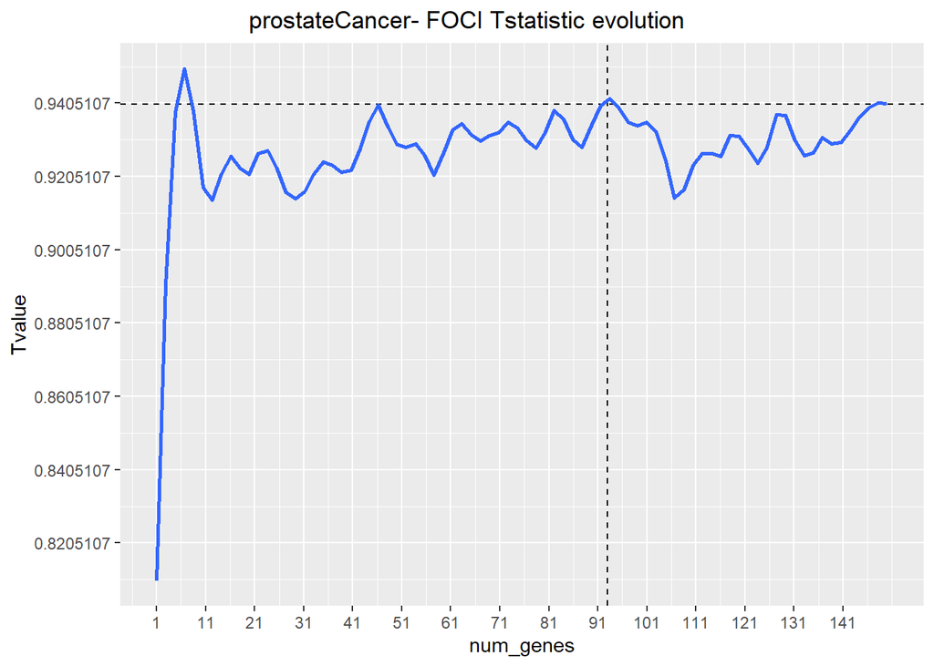

```r
load(paste0(dataset_files_folder_unsupervised,
            dataset_name,"_9_resfoci.RData"))

# Mostramos la evolucion del estadistico de dependencia en funcion del numero de atributos
foci_evolucion <- data.frame(
  num_genes = 1:num_genes,
  Tvalue = resfoci$stepT[1:num_genes]
)

xline <- num_genes_selected
yline <- foci_evolucion[num_genes_selected, "Tvalue"]

ggplot(foci_evolucion,
       aes(x =num_genes, y = Tvalue),
       main=paste0(dataset_name,"- FOCI T statistic evolution")) +
  geom_vline(aes(xintercept = xline), linetype = "dashed") +
  geom_hline(aes(yintercept = yline), linetype = "dashed") +
  geom_smooth(method = "loess", se = FALSE, span = 0.1) +
  ggtitle(paste0(dataset_name,"- FOCI Tstatistic evolution")) +
  theme(plot.title.position = "plot", plot.title = element_text(hjust = 0.5))+
  scale_x_continuous(breaks = seq(min(foci_evolucion$num_genes), max(foci_evolucion$num_genes), by = 10)) +
  scale_y_continuous(breaks = seq(min(foci_evolucion$Tvalue), max(foci_evolucion$Tvalue), by = 0.02))
```

```r
# En vista del gráfico seleccionamos como variables de interés los primeros 93 genes
# (que es donde podemos visualizar un pico para un numero considerable de genes)
```

```r
# Mostramos el listado de genes relevantes
resfoci_genes <- resfoci$selectedVar$names[1:num_genes_selected]
resfoci_genes
```

```
##  [1] "MEG3"         "HMGA1"        "SLITRK5"      "PRSS22"       "LOC102724760"
##  [6] "MAT2A"        "CNTFR"        "OCEL1"        "AQP5"         "DCT"
## [11] "PRKACB"       "H4C11"        "BMP1"         "ATP10B"       "FANCG"
## [16] "GPR171"       "PCBP1"        "ACTN3"        "AGT"          "ARPC5"
## [21] "ADAM15"       "ADAM19"       "SKAP2"        "TMED2"        "CAMK2B"
## [26] "DEFB4A"       "ILF2"         "ING2"         "CHIT1"        "RPL9"
## [31] "CCL16"        "PPT2"         "FDXR"         "G6PD"         "PPP1R16B"
## [36] "AIMP1"        "CD72"         "ABHD2"        "CNP"          "DMTN"
## [41] "GAB1"         "CTAG1B"       "KIAA0586"     "ZNRD1ASP"     "CADM3"
## [46] "VAMP5"        "GNB2"         "BECN1"        "GAGE12J"      "ADSS2"
## [51] "ACAA1"        "COL19A1"      "CALCOCO1"     "KCNH2"        "CNTN6"
## [56] "CSRP3"        "KIAA0895"     "CBX2"         "ITGA2B"       "CAPN2"
## [61] "NFYB"         "CXCL5"        "ARHGAP44"     "CELA2B"       "CDK5R1"
## [66] "USP32P2"      "PCDHA9"       "AATF"         "CAPRIN1"      "ROS1"
## [71] "HMGA2"        "CD48"         "CLCN5"        "ACACA"        "PPM1D"
## [76] "FAM247C"      "ALOX12"       "COL6A3"       "CHAF1A"       "KAT6A"
## [81] "H3P6"         "GRB10"        "CDC42EP3"     "AANAT"        "FTO"
## [86] "EFNB3"        "ITGB1BP1"     "AKR7A2"       "ATG4B"        "FAM153B"
## [91] "DNM1L"        "C10orf95"     "ATP5MJ"
```

# Redes de co-expresión

Podemos cargar el listado de genes en GeneMANIA y obtenemos el siguiente grafo.

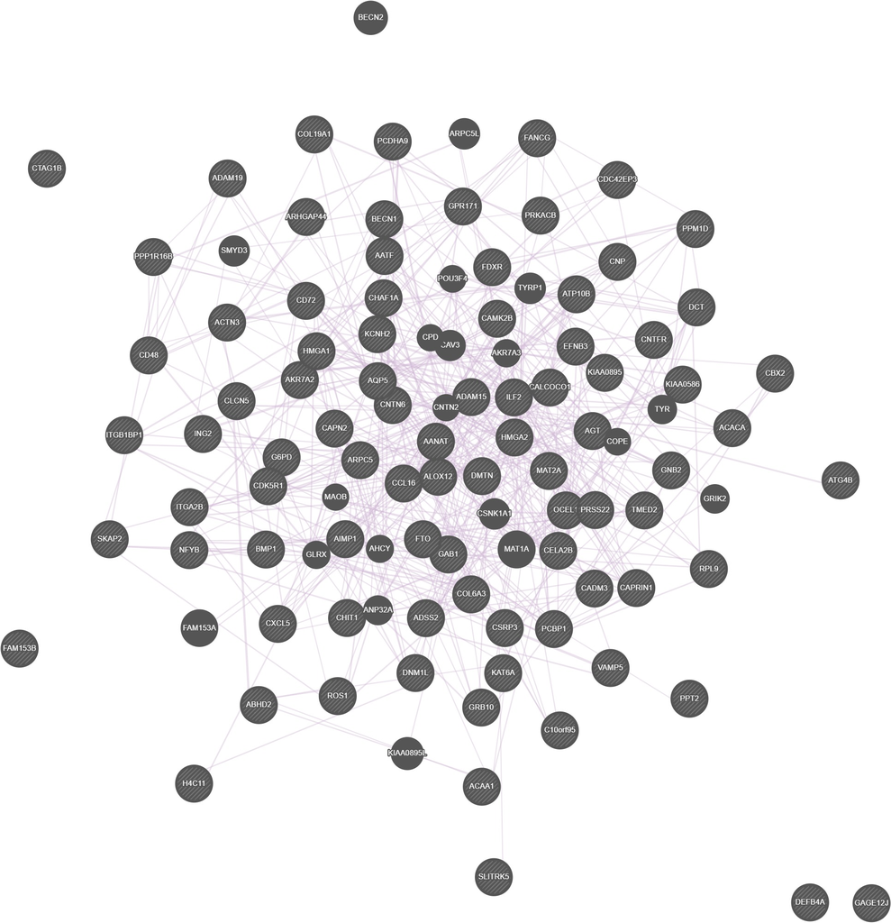

```r
knitr::include_graphics(paste0(dataset_files_folder_unsupervised,
                               dataset_name,"_9_genemania.jpg")
                        )
```

# Buscamos redes de interacción entre las características

Para discretizar los valores debemos de tener en cuenta como se distribuyen los valores de expresión de los distintos genes. Si son muy dispares utilizaremos una discretización basada en la mediana, si no podremos utilizar un umbral estático.

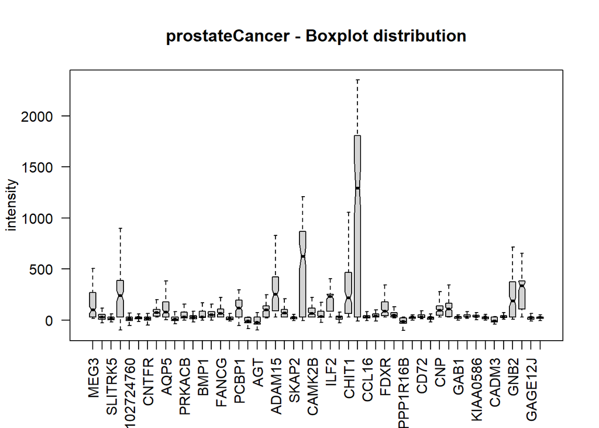

```r
# Boxplot: distribuciones de cuantiles de las intensidades de gen

boxplot(gene_matrix[,resfoci_genes][,1:nmax_boxplot], boxwex=0.7, notch=T,
        main=paste(dataset_name, "- Boxplot distribution"),
        ylab = "intensity",
        outline=FALSE, las=2)
```

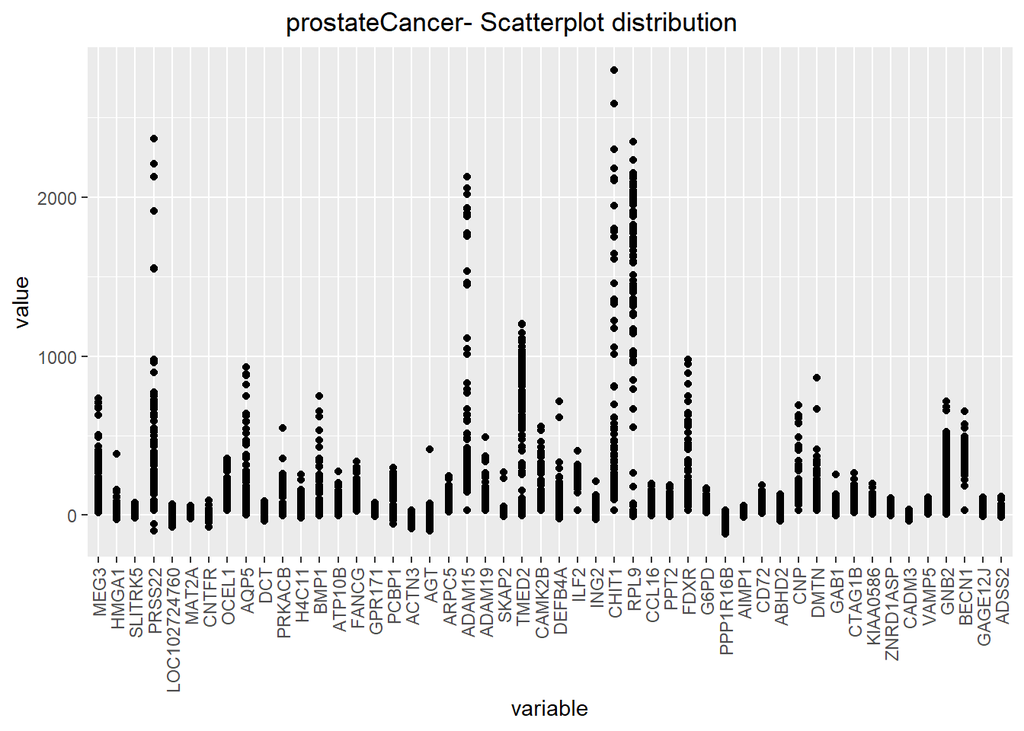

```r
# Scatterplot: intensidades de gen utilizando gráfico de puntos

gene_matrix_melt <- melt(gene_matrix[,resfoci_genes][,1:nmax_boxplot])
ggplot(gene_matrix_melt,
       aes(x=variable, y=value)) +
  geom_point() +
  ggtitle(paste0(dataset_name, "- Scatterplot distribution")) +
  theme(plot.title.position = "plot", plot.title = element_text(hjust = 0.5),
        axis.text.x = element_text(angle = 90, vjust = 0.5, hjust=1)
        )
```

Conversión del conjunto de datos a transacciones.

```r
# El valor de un gen se considerara alto si esta por encima de su mediana y bajo en caso contrario

dataset_discretizado <- dataset[,resfoci_genes]
dataset_discretizado <- apply(dataset_discretizado, 2,
                              function(x) ifelse(x < median(x, na.rm = TRUE), "bajo", "alto"))
dataset_discretizado <- cbind(
  group=ifelse(dataset$group == 0, groupv0, groupv1),
  dataset_discretizado
  )
dataset_discretizado <- as.data.frame(apply(dataset_discretizado, 2, as.factor))

rownames(dataset_discretizado) <- paste0("Transaction-", c(1:nrow(dataset_discretizado)))

transactions_dataset <- transactions(dataset_discretizado)
```

```r
antecedente <- c(paste0(resfoci_genes,"=alto"), paste0(resfoci_genes,"=bajo"), antecedente_extra)
consecuente <- c(paste0("group=",groupv1))

apariencia <- list(
    lhs = antecedente,
    rhs = consecuente
)
```

Ajustamos los parámetros de interés de las reglas: - Soporte mínimo. El soporte mide el número de muestras que satisfacen la regla. Exigiremos un soporte superior a 0.25 para garantizar que las reglas cubren un cierto número de ejemplos (y evitar sobreajuste). - Confianza. La confianza representa la tasa de aciertos de la regla. En nuestro caso nos interesa garantizar que las reglas sean fiables, por lo que estableceremos la confianza a 1. - Lift. Este parámetro mide el grado de dependencia entre las variables del antecedente y el consecuente. Si la relación es baja, la regla es poco informativa. Valores de lift superiores a 1 indican que antecedente y consecuente ocurren juntos más de lo esperado y que, por lo tanto, la regla es bastante informativa. Estableceremos un valor de lift superior a 1.7.

```r
# Obtencion de reglas con los parametros indicados

reglas <- apriori(transactions_dataset, parameter = list(
  supp = min_supp,
  conf = min_conf,
  maxlen = maxlen_rules,
  maxtime=maxtime_rules),
  appearance = apariencia
)
```

```
## Apriori
##
## Parameter specification:
##  confidence minval smax arem  aval originalSupport maxtime support minlen
##        0.95    0.1    1 none FALSE            TRUE      60     0.2      1
##  maxlen target  ext
##       4  rules TRUE
##
## Algorithmic control:
##  filter tree heap memopt load sort verbose
##     0.1 TRUE TRUE  FALSE TRUE    2    TRUE
##
## Absolute minimum support count: 27
##
## set item appearances ...[187 item(s)] done [0.00s].
## set transactions ...[187 item(s), 136 transaction(s)] done [0.00s].
## sorting and recoding items ... [187 item(s)] done [0.00s].
## creating transaction tree ... done [0.00s].
## checking subsets of size 1 2 3 4 done [0.63s].
## writing ... [4319 rule(s)] done [0.09s].
## creating S4 object  ... done [0.04s].
```

```r
reglas_mejores <- subset(reglas, subset = lift > min_lift &
                         support > 0.25 & confidence == 1)
```

```r
# Eliminación de reglas redundantes
elimina_redundantes <- function(reglas) {

  indices_no_redundantes <- c()

  for (i in 1:(length(reglas)-1)) {
    es_redundante <- FALSE

    antecedente_i <- LIST(lhs(reglas[i]))[[1]]

    for (j in (i+1):length(reglas)) {

      antecedente_j <- LIST(lhs(reglas[j]))[[1]]

      if (all(antecedente_i %in% antecedente_j)) {
        es_redundante <- TRUE
        break
      }
    }

    if (!es_redundante) {
      indices_no_redundantes <- c(indices_no_redundantes, i)
    }
  }
  return(reglas[indices_no_redundantes])
}

reglas_no_redundantes <- elimina_redundantes(reglas_mejores)

# Ordenación de reglas y visualización
reglas_ordenadas <- sort(reglas_no_redundantes, by=criterion_sort_rules, decreasing=c(TRUE, TRUE))
inspectDT(reglas_ordenadas)
```

|  | LHS | RHS | support | confidence | coverage | lift | count |
| --- | --- | --- | --- | --- | --- | --- | --- |
| [1078] | {VAMP5=bajo,ALOX12=bajo,C10orf95=bajo} | {group=tumor} | 0.294117647058824 | 1 | 0.294117647058824 | 1.76623376623377 | 40 |
| [1035] | {VAMP5=bajo,CNTN6=bajo,C10orf95=bajo} | {group=tumor} | 0.286764705882353 | 1 | 0.286764705882353 | 1.76623376623377 | 39 |
| [1074] | {GPR171=bajo,VAMP5=bajo,ALOX12=bajo} | {group=tumor} | 0.286764705882353 | 1 | 0.286764705882353 | 1.76623376623377 | 39 |
| [1075] | {VAMP5=bajo,ALOX12=bajo,H3P6=alto} | {group=tumor} | 0.286764705882353 | 1 | 0.286764705882353 | 1.76623376623377 | 39 |
| [1305] | {HMGA1=alto,VAMP5=bajo,CAPRIN1=alto} | {group=tumor} | 0.286764705882353 | 1 | 0.286764705882353 | 1.76623376623377 | 39 |
| [1334] | {HMGA1=alto,GPR171=bajo,VAMP5=bajo} | {group=tumor} | 0.286764705882353 | 1 | 0.286764705882353 | 1.76623376623377 | 39 |
| [1363] | {HMGA1=alto,ZNRD1ASP=bajo,VAMP5=bajo} | {group=tumor} | 0.286764705882353 | 1 | 0.286764705882353 | 1.76623376623377 | 39 |
| [1389] | {HMGA1=alto,VAMP5=bajo,C10orf95=bajo} | {group=tumor} | 0.286764705882353 | 1 | 0.286764705882353 | 1.76623376623377 | 39 |
| [1403] | {HMGA1=alto,VAMP5=bajo,ACAA1=alto} | {group=tumor} | 0.286764705882353 | 1 | 0.286764705882353 | 1.76623376623377 | 39 |
| [1415] | {HMGA1=alto,VAMP5=bajo,GAGE12J=bajo} | {group=tumor} | 0.286764705882353 | 1 | 0.286764705882353 | 1.76623376623377 | 39 |

[output cut: 86 more lines]

```r
# Guardar los resultados
save(reglas_ordenadas, file=paste0(dataset_files_folder_unsupervised,
                                   dataset_name,"_9_reglas.RData"))

file_reglas <- file(paste0(dataset_files_folder_unsupervised,
                           dataset_name,"_9_reglas.txt"),
                    open = "w")
write(reglas_ordenadas, file = file_reglas)
```

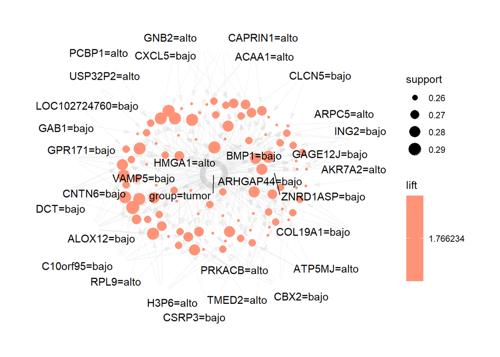

```r
# Representación de resultados
plot(reglas_ordenadas, method = "graph")
```

```r
plot(reglas_ordenadas, method = "graph", engine = "html")
```

[interactive chart not shown]